# Ejercicio Regresion Logistica (básico)

S. Perez

2025

## Ejercicio 1

Aplicar el modelo de regresion logistica al conjunto de datos de los Indios Pima, para la deteccion de la diabetes. El conjunto de datos tiene la siguiente informacion:

- *Pregnancies:* numero de embarazos.
- *glu:* concentracion plasmatica de glucosa en una prueba oral de tolerancia a la glucosa.
- *BloodPressure:* presion arterial diastolica (mm Hg).
- *SkinThickness:* espesor de la piel en el pliegue del triceps (mm).
- *Insulin:* niveles de insulina en suero.
- *bmi:* indice de masa corporal (peso en kg / (altura en m)^2).
- *DiabetesPedigreeFunction:* funcion de pedigree de diabetes.
- *age:* edad en años.
- *Outcome:* diagnostico de diabetes (0: negativo; 1: positivo).

Lo primero que hacemos es cargar los paquetes que vamos a utilizar:

```r
# Librerias
library(readxl)
library(dplyr)
library(ggplot2)
library(gridExtra)
library(caret)
library(vcd)
library(MASS)
library(ROCR)
library(pROC)
```

1. Realizar un analisis exploratorio de los datos.

```r
#Cargamos los datos.
pima <- read_excel("diabetes.xls")

#Primeros 6 Observaciones.
head(pima)
```

| Pregnancies | Glucose | BloodPressure | SkinThickness | Insulin | BMI | DiabetesPedigreeFunction | Age | Outcome |
| --- | --- | --- | --- | --- | --- | --- | --- | --- |
| 6 | 148 | 72 | 35 | 0 | 33.6 | 0.627 | 50 | 1 |
| 1 | 85 | 66 | 29 | 0 | 26.6 | 0.351 | 31 | 0 |
| 8 | 183 | 64 | 0 | 0 | 23.3 | 0.672 | 32 | 1 |
| 1 | 89 | 66 | 23 | 94 | 28.1 | 0.167 | 21 | 0 |
| 0 | 137 | 40 | 35 | 168 | 43.1 | 2.288 | 33 | 1 |
| 5 | 116 | 74 | 0 | 0 | 25.6 | 0.201 | 30 | 0 |

```r
#Estructura de los datos.
glimpse(pima)
```

```
## Rows: 768
## Columns: 9
## $ Pregnancies              <dbl> 6, 1, 8, 1, 0, 5, 3, 10, 2, 8, 4, 10, 10, 1, …
## $ Glucose                  <dbl> 148, 85, 183, 89, 137, 116, 78, 115, 197, 125…
## $ BloodPressure            <dbl> 72, 66, 64, 66, 40, 74, 50, 0, 70, 96, 92, 74…
## $ SkinThickness            <dbl> 35, 29, 0, 23, 35, 0, 32, 0, 45, 0, 0, 0, 0, …
## $ Insulin                  <dbl> 0, 0, 0, 94, 168, 0, 88, 0, 543, 0, 0, 0, 0, …
## $ BMI                      <dbl> 33.6, 26.6, 23.3, 28.1, 43.1, 25.6, 31.0, 35.…
## $ DiabetesPedigreeFunction <dbl> 0.627, 0.351, 0.672, 0.167, 2.288, 0.201, 0.2…
## $ Age                      <dbl> 50, 31, 32, 21, 33, 30, 26, 29, 53, 54, 30, 3…
## $ Outcome                  <dbl> 1, 0, 1, 0, 1, 0, 1, 0, 1, 1, 0, 1, 0, 1, 1, …
```

Todas las variables aparecen como numéricas, incluida la variable *Outcome* que utilizamos como variable dependiente, por lo que nuestro objetivo es identificar si un paciente tiene diabetes o no. La debemos transformar en factor para realizar un modelo de regresion logistica, si no lo hicieramos la funcion nos indicara que no estamos ante un problema con una variable binomial.

2. Ajustar a un modelo de regresion logistica que permita predecir posibles resultados en la deteccion diabetes en los *indios pima*, a partir del indice de masa corporal.

```r
# Transformacion en factor
pima$Outcome <- as.factor(pima$Outcome)
```

Realizamos un summary() para ver los estadisticos basicos y comprobar que no hay datos ausentes.

```r
#Estadisticas
summary(pima)
```

```
##   Pregnancies        Glucose      BloodPressure    SkinThickness
##  Min.   : 0.000   Min.   :  0.0   Min.   :  0.00   Min.   : 0.00
##  1st Qu.: 1.000   1st Qu.: 99.0   1st Qu.: 62.00   1st Qu.: 0.00
##  Median : 3.000   Median :117.0   Median : 72.00   Median :23.00
##  Mean   : 3.845   Mean   :120.9   Mean   : 69.11   Mean   :20.54
##  3rd Qu.: 6.000   3rd Qu.:140.2   3rd Qu.: 80.00   3rd Qu.:32.00
##  Max.   :17.000   Max.   :199.0   Max.   :122.00   Max.   :99.00
##     Insulin           BMI        DiabetesPedigreeFunction      Age
##  Min.   :  0.0   Min.   : 0.00   Min.   :0.0780           Min.   :21.00
##  1st Qu.:  0.0   1st Qu.:27.30   1st Qu.:0.2437           1st Qu.:24.00
##  Median : 30.5   Median :32.00   Median :0.3725           Median :29.00
##  Mean   : 79.8   Mean   :31.99   Mean   :0.4719           Mean   :33.24
##  3rd Qu.:127.2   3rd Qu.:36.60   3rd Qu.:0.6262           3rd Qu.:41.00
##  Max.   :846.0   Max.   :67.10   Max.   :2.4200           Max.   :81.00
##  Outcome
##  0:500
##  1:268
##
##
##
##
```

No hay valores NA.

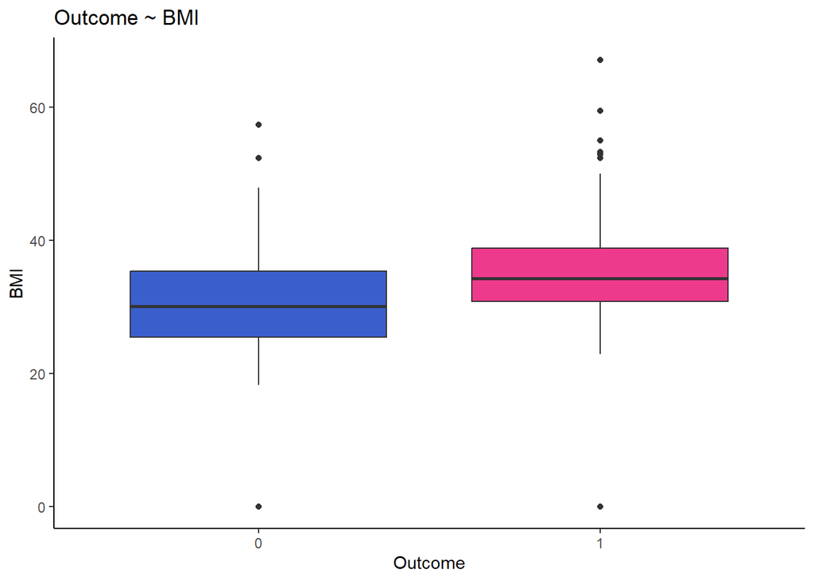

```r
#Outcome ~ BMI
ggplot(pima, aes(x = Outcome, y = BMI)) +
geom_boxplot(fill = c("royalblue3", "violetred2")) +
labs(title = "Outcome ~ BMI") +
theme_classic()
```

Se obtiene un grafico donde observamos diferencias entre las dos categorias, con medianas distintas y rangos intercuartilicos distintos. Ademas, observamos que existen datos atipicos en las dos categorias.

La variable BMI podria ser una variable importante para predecir si una persona tiene diabetes o no, al tener diferencias entre las dos categorias de la variable dependiente.

Si utilizamos una regresion lineal para predecir la variable **outcome**, lo podemos realizar con la *funcion plot()*, donde indicamos las dos variables y le añadimos la *funcion abline()* que nos permite crear una regresion lineal con la *funcion lm()*.

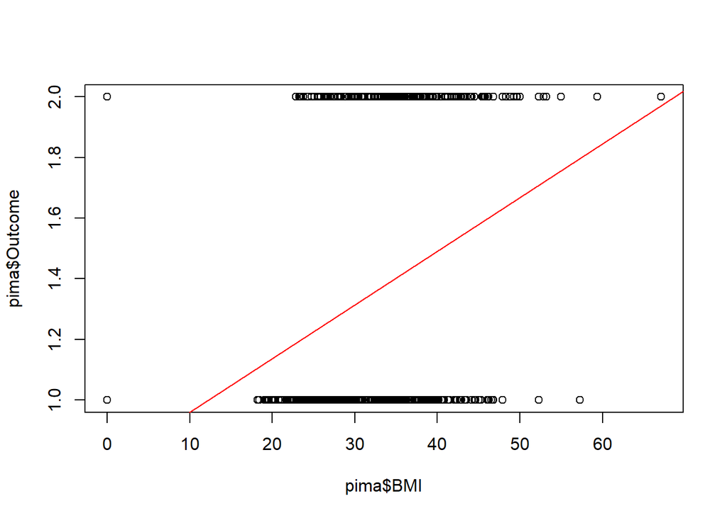

```r
#Regresion lineal????
plot(pima$BMI, pima$Outcome)
abline(lm(pima$Outcome~pima$BMI), col = "red")
```

En el grafico se observa una recta, y se puede ver que no es un buen modelo!

Una vez que hemos visto como se relacionan las dos variables, la variable dependiente y la predictora, se demuestra que no es valida la regresion lineal. Por lo que creamos el *modelo logistico simple* con la *funcion glm()* que nos sirve para crear modelos lineales generalizados.

Esta funcion se utiliza del mismo modo que la *funcion lm()* de la regresion lineal, pero le añadimos el argumento *family = binomial*, para indicarle que estamos ante una regresion logistica con una variable dependiente de dos categorias. Realizamos un *summary()* con el modelo entrenado.

La *funcion summary()* nos proporciona la siguiente informacion:

- La formula utilizada.
- Estadisticas de los residuos.
- Los coeficientes estimados: intercepto y coeficiente de la variable BMI.
- Los errores estandar, el valor del estadistico, el p-value para el intercepto y el coeficiente de BMI.
- Residual deviance, que nos indica la falta de ajuste de los datos en un modelo de regresion logistica.
- La Null deviance, que nos indica la diferencia entre un modelo con solo la interseccion y un modelo con un ajuste teoricamente perfecto.
- El AIC, que nos indica la cantidad relativa de informacion perdida por un modelo dado.

```r
#Modelo Logistico Simple: Outcome ~ BMI
model_log_1 <- glm(Outcome ~ BMI, data = pima, family = "binomial")
summary(model_log_1)
```

```
##
## Call:
## glm(formula = Outcome ~ BMI, family = "binomial", data = pima)
##
## Coefficients:
##             Estimate Std. Error z value Pr(>|z|)
## (Intercept) -3.68641    0.40896  -9.014  < 2e-16 ***
## BMI          0.09353    0.01205   7.761 8.45e-15 ***
## ---
## Signif. codes:  0 '***' 0.001 '**' 0.01 '*' 0.05 '.' 0.1 ' ' 1
##
## (Dispersion parameter for binomial family taken to be 1)
##
##     Null deviance: 993.48  on 767  degrees of freedom
## Residual deviance: 920.71  on 766  degrees of freedom
## AIC: 924.71
##
## Number of Fisher Scoring iterations: 4
```

En los resultados tanto el intercepto como para la variable de BMI son significativas al tener un p-value < 0.05. El p-value nos indica la probabilidad de que el coeficiente sea cero.

El objetivo de nuestro modelo es minimizar la Residual deviance, indicando que valores mas pequeños tiene un mejor ajuste.

Veamosla significatividad del modelo:

- $H_0:$ El modelo no es significativo.
- $H_1:$ El modelo es significativo.

El estadistico se calcula como la diferencia entre el error del modelo solo con la interseccion, menos el error del modelo con las variables explicativas. Los pasos son:

1. Restamos la desvianza nula menos la desvianza residual del modelo.
2. Restamos los grados de libertad del modelo nulo menos los grados de libertad del modelo.
3. Utilizamos la *funcion pchisq()* donde indicamos: la diferencia de los residuos, la diferencia de los grados de libertad y lower.tail = F para indicar que solo utilice el lado derecho de la distribucion.
3. Evaluar el modelo planteado.

```r
# Significatividad del modelo por devianzas.
# "A mano": test de diferencia de devianzas.
residuos_log_1 <- model_log_1$null.deviance - model_log_1$deviance

#Grados de Libertad.
grados_log_1 <- model_log_1$df.null - model_log_1$df.residual

#p-value.
pchisq(residuos_log_1, grados_log_1,lower.tail = F)
```

```
## [1] 1.456935e-17
```

El valor obtenido es muy cercano a cero e inferior a un p-valor de 0.05. Podemos rechazar la hipotesis nula ($H_0$) e indicar que el modelo es significativo.

Una vez que hemos comprobado que nuestro modelo es significativo, interpretamos los coeficientes del modelo que podemos obtener con la *funcion coefficients()*.

4. Interpretar los coeficientes del modelo.

```r
#Coeficientes
coefficients(model_log_1)
```

```
## (Intercept)         BMI
## -3.68641284  0.09353049
```

En regresion logistica las betas indican el cambio en el logaritmo de odds debido al incremento de una unidad.

Para interpretar los coeficientes, tenemos que hacer una transformacion de estos, interpretando el exponencial del coeficiente (exp(beta) = OR).

```r
#Transformacion de los coeficientes
exp(coefficients(model_log_1))
```

```
## (Intercept)         BMI
##  0.02506174  1.09804408
```

El coeficiente de la variable BMI es de 0.09353049, al que le aplicamos la exponencial, obteniendo la razon de odd que es igual a 1.09804408.

$log(\frac{p(X)}{1-p(X)})=\beta_0+\beta_1*X$

5. Obtener el intervalo de confianza de los coef del modelo.

Si quisieramos obtener los intervalos de confianza a un 95% de confianza podemos obtenerlos con la *funcion confint()*.

```r
#Intervalos de confianza:
confint(model_log_1)
```

```
##                   2.5 %     97.5 %
## (Intercept) -4.50912343 -2.9051697
## BMI          0.07045954  0.1177311
```

## Ejercicio 2

Entrenar un modelo de regresion logistica múltiple con el conjunto de datos de los Indios Pima para la deteccion de la diabetes, en funcion de las variables que considere convenientes.

1. Visualizar las variables independientes en funcion de la variable a predecir.

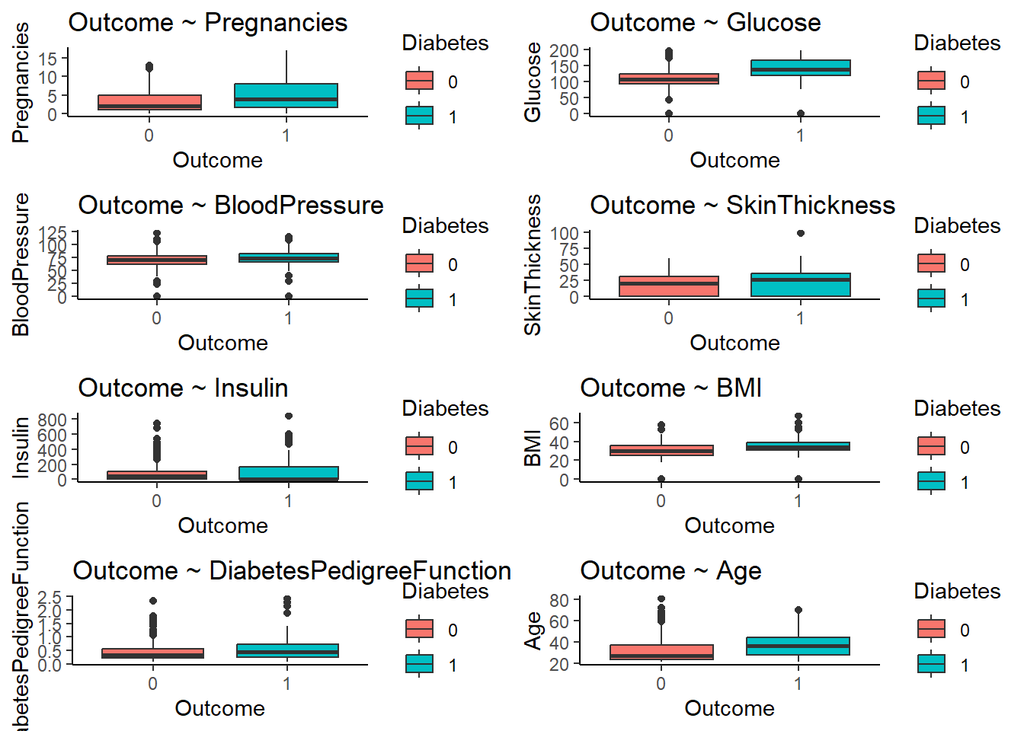

```r
#Outcome ~ Pregnancies
p <- ggplot(pima, aes(x = Outcome, y = Pregnancies, fill=Outcome)) +
  geom_boxplot() +
  labs(title = "Outcome ~ Pregnancies") +
  scale_fill_discrete(name = "Diabetes") +
  theme_classic()

#Outcome ~ Glucose
g <- ggplot(pima, aes(x = Outcome, y = Glucose, fill=Outcome)) +
  geom_boxplot() +
  labs(title = "Outcome ~ Glucose") +
  scale_fill_discrete(name = "Diabetes") +
  theme_classic()

#Outcome ~ BloodPressure
bl <- ggplot(pima, aes(x = Outcome, y = BloodPressure,
                        fill=Outcome)) +
  geom_boxplot() +
  labs(title = "Outcome ~ BloodPressure") +
  scale_fill_discrete(name = "Diabetes") +
  theme_classic()

#Outcome ~ SkinThickness
s <- ggplot(pima, aes(x = Outcome, y = SkinThickness,
                       fill=Outcome)) +
  geom_boxplot() +
  labs(title = "Outcome ~ SkinThickness") +
  scale_fill_discrete(name = "Diabetes") +
  theme_classic()

#Outcome ~ Insulin
i <- ggplot(pima, aes(x = Outcome, y = Insulin, fill=Outcome)) +
  geom_boxplot() +
  labs(title = "Outcome ~ Insulin") +
  scale_fill_discrete(name = "Diabetes") +
  theme_classic()

#Outcome ~ BMI
b <- ggplot(pima, aes(x = Outcome, y = BMI, fill=Outcome)) +
  geom_boxplot() +
  labs(title = "Outcome ~ BMI") +
  scale_fill_discrete(name = "Diabetes") +
  theme_classic()

#Outcome ~ DiabetesPedigreeFunction
d <- ggplot(pima, aes(x = Outcome, y = DiabetesPedigreeFunction,
                       fill=Outcome)) +
  geom_boxplot() +
  labs(title = "Outcome ~ DiabetesPedigreeFunction") +
  scale_fill_discrete(name = "Diabetes") +
  theme_classic()

#Outcome ~ Age
a <- ggplot(pima, aes(x = Outcome, y = Age, fill=Outcome)) +
  geom_boxplot() +
  labs(title = "Outcome ~ Age") +
  scale_fill_discrete(name = "Diabetes") +
  theme_classic()

grid.arrange(p,g,bl,s,i,b,d,a,  ncol = 2)
```

Observamos que hay diferencias entre las dos categorias, tanto en las medianas como en la distribucion y podrian ser importantes para modelar la variable dependiente en: glucosa, bmi y numero de embarazos.

Otras variables parece que no van a ser utiles para predecir la variable dependiente como son: insulina, el espesor de la piel, o la presion arterial. Veremos..!

Vamos a trabajar con conjuntos de entrenamiento y validación:

```r
set.seed(135)
#Dividimos el conjunto de datos
index <- createDataPartition(pima$Outcome, p = 0.70,list = FALSE)
train <- pima[index,]
test <- pima[-index,]
#Dimensiones
dim(train)
```

```
## [1] 538   9
```

```r
dim(test)
```

```
## [1] 230   9
```

2. Ajustar un modelo de regresion logistica que permita predecir la deteccion de diabetes en los Indios Pima, a partir de las variables en estudio.

```r
#Modelo Logistico completo
modelo_full <- glm(Outcome ~ ., family = "binomial", data = train)
summary(modelo_full)
```

```
##
## Call:
## glm(formula = Outcome ~ ., family = "binomial", data = train)
##
## Coefficients:
##                            Estimate Std. Error z value Pr(>|z|)
## (Intercept)              -8.5410210  0.8841136  -9.661  < 2e-16 ***
## Pregnancies               0.1312418  0.0388435   3.379 0.000728 ***
## Glucose                   0.0337389  0.0044959   7.504 6.17e-14 ***
## BloodPressure            -0.0163324  0.0068102  -2.398 0.016476 *
## SkinThickness             0.0021193  0.0084338   0.251 0.801589
## Insulin                  -0.0006702  0.0010818  -0.620 0.535550
## BMI                       0.1037431  0.0186538   5.562 2.67e-08 ***
## DiabetesPedigreeFunction  1.2106464  0.3733355   3.243 0.001184 **
## Age                       0.0111158  0.0111262   0.999 0.317762
## ---
## Signif. codes:  0 '***' 0.001 '**' 0.01 '*' 0.05 '.' 0.1 ' ' 1
##
## (Dispersion parameter for binomial family taken to be 1)
##
##     Null deviance: 696.28  on 537  degrees of freedom
## Residual deviance: 499.97  on 529  degrees of freedom
## AIC: 517.97
##
## Number of Fisher Scoring iterations: 5
```

Con la funcion *summary()* se puede observar que algunas de las variables tienen un p-valor superior a 0.05 como son: años,insulina o espesor de la piel, no son significativas.

3. Ajustar modelos según distintos criterios.

Aplicamos un metodo de selecion:

```r
#Seleccion del modelo
modelo_2<- stepAIC(modelo_full)
```

```
## Start:  AIC=517.97
## Outcome ~ Pregnancies + Glucose + BloodPressure + SkinThickness +
##     Insulin + BMI + DiabetesPedigreeFunction + Age
##
##                            Df Deviance    AIC
## - SkinThickness             1   500.04 516.04
## - Insulin                   1   500.35 516.35
## - Age                       1   500.96 516.96
## <none>                          499.97 517.97
## - BloodPressure             1   505.85 521.85
## - DiabetesPedigreeFunction  1   511.02 527.02
## - Pregnancies               1   511.83 527.83
## - BMI                       1   537.29 553.29
## - Glucose                   1   569.47 585.47
##
## Step:  AIC=516.04
## Outcome ~ Pregnancies + Glucose + BloodPressure + Insulin + BMI +
##     DiabetesPedigreeFunction + Age
##
##                            Df Deviance    AIC
## - Insulin                   1   500.35 514.35
## - Age                       1   500.98 514.98
## <none>                          500.04 516.04
## - BloodPressure             1   505.89 519.89
## - DiabetesPedigreeFunction  1   511.36 525.36
## - Pregnancies               1   512.04 526.04
## - BMI                       1   542.72 556.72
## - Glucose                   1   570.95 584.95
##
## Step:  AIC=514.35
## Outcome ~ Pregnancies + Glucose + BloodPressure + BMI + DiabetesPedigreeFunction +
##     Age
##
##                            Df Deviance    AIC
## - Age                       1   501.40 513.40
## <none>                          500.35 514.35
## - BloodPressure             1   506.35 518.35
## - DiabetesPedigreeFunction  1   511.36 523.36
## - Pregnancies               1   512.60 524.60
## - BMI                       1   542.72 554.72
## - Glucose                   1   578.82 590.82
##
## Step:  AIC=513.4
## Outcome ~ Pregnancies + Glucose + BloodPressure + BMI + DiabetesPedigreeFunction
##
##                            Df Deviance    AIC
## <none>                          501.40 513.40
## - BloodPressure             1   506.77 516.77
## - DiabetesPedigreeFunction  1   512.49 522.49
## - Pregnancies               1   523.24 533.24
## - BMI                       1   542.76 552.76
## - Glucose                   1   586.27 596.27
```

```r
summary(modelo_2)
```

```
##
## Call:
## glm(formula = Outcome ~ Pregnancies + Glucose + BloodPressure +
##     BMI + DiabetesPedigreeFunction, family = "binomial", data = train)
##
## Coefficients:
##                           Estimate Std. Error z value Pr(>|z|)
## (Intercept)              -8.228048   0.831538  -9.895  < 2e-16 ***
## Pregnancies               0.152897   0.033570   4.554 5.25e-06 ***
## Glucose                   0.033377   0.004069   8.203 2.35e-16 ***
## BloodPressure            -0.015068   0.006573  -2.293  0.02187 *
## BMI                       0.101877   0.017529   5.812 6.18e-09 ***
## DiabetesPedigreeFunction  1.190283   0.365948   3.253  0.00114 **
## ---
## Signif. codes:  0 '***' 0.001 '**' 0.01 '*' 0.05 '.' 0.1 ' ' 1
##
## (Dispersion parameter for binomial family taken to be 1)
##
##     Null deviance: 696.28  on 537  degrees of freedom
## Residual deviance: 501.40  on 532  degrees of freedom
## AIC: 513.4
##
## Number of Fisher Scoring iterations: 5
```

```r
#Modelo 3
modelo_3 <- glm(Outcome ~ Pregnancies + Glucose +
                      BMI + DiabetesPedigreeFunction ,
                   family = "binomial", data = train)
summary(modelo_3)
```

```
##
## Call:
## glm(formula = Outcome ~ Pregnancies + Glucose + BMI + DiabetesPedigreeFunction,
##     family = "binomial", data = train)
##
## Coefficients:
##                           Estimate Std. Error z value Pr(>|z|)
## (Intercept)              -8.858554   0.803970 -11.019  < 2e-16 ***
## Pregnancies               0.137603   0.032535   4.229 2.34e-05 ***
## Glucose                   0.032779   0.004026   8.142 3.89e-16 ***
## BMI                       0.092150   0.016816   5.480 4.25e-08 ***
## DiabetesPedigreeFunction  1.241327   0.361550   3.433 0.000596 ***
## ---
## Signif. codes:  0 '***' 0.001 '**' 0.01 '*' 0.05 '.' 0.1 ' ' 1
##
## (Dispersion parameter for binomial family taken to be 1)
##
##     Null deviance: 696.28  on 537  degrees of freedom
## Residual deviance: 506.77  on 533  degrees of freedom
## AIC: 516.77
##
## Number of Fisher Scoring iterations: 5
```

4. Comparamos los tres modelos

```r
anova(modelo_full,modelo_2,modelo_3)
```

|  | Resid. Df | Resid. Dev | Df | Deviance | Pr(>Chi) |
| --- | --- | --- | --- | --- | --- |
| 1 | 529 | 499.9735 | NA | NA | NA |
| 2 | 532 | 501.4026 | -3 | -1.429143 | 0.69871780 |
| 3 | 533 | 506.7656 | -1 | -5.362951 | 0.02056894 |

5. Interpretar los coeficientes del modelo.

Una vez que hemos comprobado que el modelo es significativo vamos a interpretar sus coeficientes. Recordar que se deben eliminar los logaritmos con la exponencial de los coeficientes del modelo.

```r
#coeficientes
exp(coefficients(modelo_3))
```

```
##              (Intercept)              Pregnancies                  Glucose
##             0.0001421605             1.1475196347             1.0333220818
##                      BMI DiabetesPedigreeFunction
##             1.0965295000             3.4602030124
```

```r
#Variables mas importantes
varImp(modelo_3)
```

|  | Overall |
| --- | --- |
| Pregnancies | 4.229399 |
| Glucose | 8.141955 |
| BMI | 5.479997 |
| DiabetesPedigreeFunction | 3.433352 |

Las variables mas importantes son *Pregnancies, Glucose y BMI*.

7. Predecir el modelo planteado.

```r
#Realizamos las predicciones
predict_modelo_3 <- predict(modelo_3, newdata = test,
                               type = "response")
head(predict_modelo_3)
```

```
##          1          2          3          4          5          6
## 0.66661252 0.04711494 0.42709604 0.70699049 0.03316999 0.24463112
```

La funcion nos devuelve las probabilidades para cada observacion que tenemos que transformar por medio de un umbral de discriminacion. En este caso elegimos el umbral del 0.5.

```r
#Transformamos con el umbral 0.5.
prediccion_05 <- ifelse(predict_modelo_3 > 0.5, 1,0)
head(prediccion_05)
```

```
## 1 2 3 4 5 6
## 1 0 0 1 0 0
```

8. Plantear la matriz de confusion.

Una vez que tenemos la clase de cada observacion comparamos las predicciones contra los valores reales del conjunto test con la matriz de confusion.

```r
#Matriz de confusion
model3_table <- table(prediccion_05, test$Outcome,
dnn = c("prediccion","observaciones"))
model3_table
```

```
##           observaciones
## prediccion   0   1
##          0 129  34
##          1  21  46
```

Realizamos un mosaico con la *libreria vcd*, para visualizar los errores del modelo en el conjunto test.

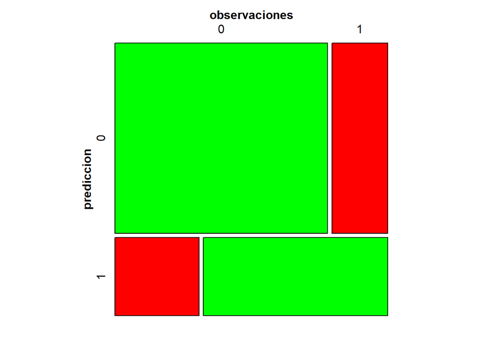

```r
mosaic(model3_table, shade = T, colorize =T,
       gp = gpar(fill = matrix(c("green","red","red","green"),2,2)))
```

La matriz de confusion nos sirve para evaluar como clasifica un modelo supervisado de clasificacion, identificando que observaciones han sido clasificadas correctamente y que observaciones el modelo no las ha clasificado correctamente.

Las observaciones con la prediccion del modelo pueden ser:

- **Verdaderos Positivos (VP):** una observacion clasificada como positiva y que realmente es positiva.
- **Verdaderos Negativos (VN):** una observacion clasificada como negativa y que realmente es negativa.
- **Falsos Positivos (FP):** una observacion clasificada como positiva y que realmente es negativa.
- **Falsos Negativos (FN):** una observacion clasificada como negativa y que realmente es positiva.
11. Determinar la sensibilidad y la especificidad del modelo.

```r
#Matriz de confusion
confusionMatrix(factor(prediccion_05),
                test$Outcome, positive = "1")
```

```
## Confusion Matrix and Statistics
##
##           Reference
## Prediction   0   1
##          0 129  34
##          1  21  46
##
##                Accuracy : 0.7609
##                  95% CI : (0.7004, 0.8145)
##     No Information Rate : 0.6522
##     P-Value [Acc > NIR] : 0.000245
##
##                   Kappa : 0.4521
##
##  Mcnemar's Test P-Value : 0.105645
##
##             Sensitivity : 0.5750
##             Specificity : 0.8600
##          Pos Pred Value : 0.6866
##          Neg Pred Value : 0.7914
##              Prevalence : 0.3478
##          Detection Rate : 0.2000
##    Detection Prevalence : 0.2913
##       Balanced Accuracy : 0.7175
##
##        'Positive' Class : 1
##
```

- **Accuracy:** se puede definir como la exactitud del modelo, es decir, el numero de predicciones que el modelo realiza correctamente. El objetivo es maximizar el Accuracy.

$Accuracy=\frac{VP+VN}{TP}$

- **Sensibilidad(recall):** nos indica los verdaderos positivos entre los verdaderos positivos y falsos negativos. El recall es importante en aquellos casos que tienen un alto coste asociado a falsos negativos (indicar que una transaccion fraudulenta no lo es).

$Sensibilidad=\frac{VP}{VP+FN}$

- **Especificidad:** nos indica los verdaderos negativos entre los verdaderos negativos y los falsos positivos.

$Especificidad=\frac{VN}{VN+FP}$

- **Precisión:** nos indica los verdaderos positivos entre los pronosticados como positivos.

$Precisión=\frac{VP}{VP+FP}$

- **Prevalencia:** Es la proporción de observaciones del conjunto que presentan la clase positiva. La prevalencia nos sirve como puntuacion base para nuestros modelos. Tendra que superar como minimo a la prevalencia.

$Prevalencia=\frac{Total_Positivos}{Total_{Observaciones}}$